# Homework4 市长电话分析

20210980108 颜帆

**数据说明：train_set.csv/test_set.csv**

市长电话数据集是某北方城市政府部门冬季收到的“12345”服务热线的来电信息记录。数据集中的变量包括:  
(1) 单位名称：即每一条来电信息记录最 终受理的政府部门；  
(2) 词汇出现的频数：已有词汇表中各个词汇在投诉建议的文本内容中出现的频数。  
数据总共有 2000 行，每一行代表一条投诉建议中各个词汇的出现频数，第 2-6236列的列名为某个词汇。

**分析任务：**

1. 读入市长电话训练集 train_set.csv 和测试集 test_set.csv，统计训练集中各个政府单位接到的市民投诉量，并绘制柱状图（按照投诉量降序），简单陈述你观察到的现象；
2. 统计每条投诉用词数并绘制分布直方图，简要分析你观察到的结果；
3. 并将各单位收集到投诉信息分词后总词数的差异用箱线图表示出来，尝试解读这个箱线图呈现的现象；
4. 以训练集中的政府单位为因变量类别，电话文本为自变量，尝试用朴素贝叶斯方法对市政电话文本进行分类，并使用该模型对测试集电话文本进行预测，计算混淆矩阵，简要分析模型的效果（提示：由于投诉建议文本整体长度较短，将每个词汇的被使用频数用是（1）-否（0）被使用替代，更为简便）

## 分析任务一

读入市长电话训练集 train_set.csv 和测试集 test_set.csv，统计训练集中各个政府单位接到的市民投诉量，并绘制柱状图（按照投诉量降序），简单陈述你观察到的现象；

### 读入数据

使用np.loadtxt函数读入市长电话训练集 train_set.csv 和测试集 test_set.csv并将其结果array转为dataframe，并将其展示。可以发现，一共有1900行训练集和100行测试集，每一行代表一条投诉建议中各个词汇出现的频数，投诉词汇包含换车、商户、吉林大路等等，一共有6235个投诉建议词汇。第一列为政府部门的单位名称，一共有七个公司。整个数据集为七个政府部门收到的两千条投诉建议的词汇记录。

```python
import pandas as pd
import numpy as np
import matplotlib.pyplot as plt
```

```python
lines = np.loadtxt('train_set.csv', delimiter=',', dtype='str',encoding='utf-8')
test_lines = np.loadtxt('test_set.csv', delimiter=',', dtype='str',encoding='utf-8')
```

```python
print("训练集数据大小：",lines.shape)
print("测试集数据大小：",test_lines.shape)
```

```
训练集数据大小： (1901, 6236)
测试集数据大小： (101, 6236)
```

```python
lines
```

```
array([['"单位名称"', '"换车"', '"商户"', ..., '"煦"', '"煤"', '"后门"'],
       ['"市供热公司"', '0', '0', ..., '0', '0', '0'],
       ['"市水务集团"', '0', '0', ..., '0', '0', '0'],
       ...,
       ['"市房地集团"', '0', '0', ..., '0', '0', '0'],
       ['"市水务集团"', '0', '0', ..., '0', '0', '0'],
       ['"市供电公司"', '0', '0', ..., '0', '0', '0']], dtype='<U10')
```

```python
# 去掉数据中的引号
col = np.array([x.strip('"') for x in lines[0]])
idx = np.array([x.strip('"') for x in lines[:,0]])
lines[0] = col
lines[:,0] = idx
```

```python
data = pd.DataFrame(lines[1:],columns=lines[0])
data.columns.name = "id"  ##包含id列的训练集dataframe

train = pd.DataFrame(lines[1:,1:],columns=lines[0,1:],index=lines[1:,0],dtype='int32')
train.columns.name = "单位名称"
train.head()
```

| 单位名称 | 换车 | 商户 | 吉林大路 | 还在 | 给出 | 安全标准 | 地 | 是因为 | 东北师范大学 | 违法 | ... | 绿园 | 门将 | 研究所 | 世纪家园 | 水务 | 提醒 | 照 | 煦 | 煤 | 后门 |
| --- | --- | --- | --- | --- | --- | --- | --- | --- | --- | --- | --- | --- | --- | --- | --- | --- | --- | --- | --- | --- | --- |
| 市供热公司 | 0 | 0 | 0 | 0 | 0 | 0 | 0 | 0 | 0 | 0 | ... | 0 | 0 | 0 | 0 | 0 | 0 | 0 | 0 | 0 | 0 |
| 市水务集团 | 0 | 0 | 0 | 0 | 0 | 0 | 0 | 0 | 0 | 0 | ... | 0 | 0 | 0 | 0 | 0 | 0 | 0 | 0 | 0 | 0 |
| 市水务集团 | 0 | 0 | 0 | 0 | 0 | 0 | 0 | 0 | 0 | 0 | ... | 0 | 0 | 0 | 0 | 0 | 0 | 0 | 0 | 0 | 0 |
| 市燃气集团 | 0 | 0 | 0 | 0 | 0 | 0 | 0 | 0 | 0 | 0 | ... | 0 | 0 | 0 | 0 | 0 | 0 | 0 | 0 | 0 | 0 |
| 市公交集团 | 0 | 0 | 0 | 0 | 0 | 0 | 0 | 0 | 0 | 0 | ... | 0 | 0 | 0 | 0 | 0 | 0 | 0 | 0 | 0 | 0 |

5 rows × 6235 columns

### 绘制柱状图

统计训练集中各个政府单位接到的市民投诉量，并绘制柱状图（按照投诉量降序），简单陈述你观察到的现象；

```python
index = pd.DataFrame(train.index) #提取train的单位名称，方便计算投诉量
bar_data = index[0].value_counts() #bar_data为单位名称及其接受到的投诉量的统计 为Series类型
bar_data
```

```
市水务集团     557
市供热公司     332
市运输管理局    330
市燃气集团     285
市公交集团     207
市房地集团      96
市供电公司      93
Name: 0, dtype: int64
```

```python
list = bar_data.index.tolist() #单位名称从index转到list
number = [i for i in bar_data]
```

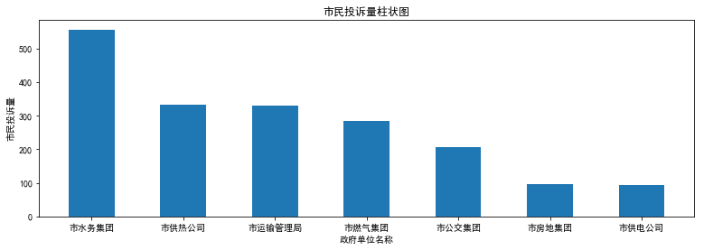

```python
plt.figure(figsize=(13, 4))
plt.rcParams['font.sans-serif']=['SimHei'] #用来正常显示中文标签
x = list
y = number
plt.xticks(np.arange(len(x)),x)   #固定x轴顺序，按市民投诉量降序输出柱状图
plt.bar(np.arange(len(x)),y,width=0.5)
plt.title("市民投诉量柱状图",fontsize='large')
plt.xlabel('政府单位名称',fontsize='medium')
plt.ylabel('市民投诉量',fontsize='medium')
plt.show()
```

从图中我们可以看到，七个政府单位中，市水务集团接受到的市民投诉量最多（557条投诉），远超过了排名第二和第三的市供热公司和市运输管理局（大概330条投诉），说明市水务集团工作服务不好，更容易被投诉。而被投诉最少的市供电公司和市房地集团，只有九十几条投诉，说明市民们对这两个政府单位的服务大多都持满意态度。

## 分析任务二

统计每条投诉用词数并绘制分布直方图，简要分析你观察到的结果； 对每一行，即每一次投诉，按行相加统计这一次投诉所用到的我们统计的投诉用词词汇的数量，并对这数量绘制分布的直方图。

```python
words = []
train["用词数"] = train.apply(lambda x:x.sum(),axis =1)
numbers = train["用词数"].values
words.append(numbers)
```

```python
print("每条投诉用词数的取值范围在[{}，{}]".format(min(words[0]),max(words[0])))
```

```
每条投诉用词数的取值范围在[3，144]
```

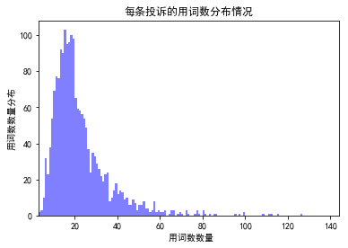

```python
bins=np.arange(3,144,1)   #以投诉用词数数量的最值为区间，1为间隔进行分箱
plt.figsize = (15,10)
plt.title("每条投诉的用词数分布情况",fontsize='large')
plt.xlabel(' 用词数数量',fontsize='medium')
plt.ylabel('用词数数量分布',fontsize='medium')
plt.hist(words,bins,color='blue',alpha=0.5)
plt.xlim(3,144)#设置x轴分布范围
plt.show()
```

从图中我们可以看出，投诉建议的用词中，最多包含144，最少包含3个我们统计的投诉词汇。大部分分布在10个到30个之间，也符合我们平时投诉说话的习惯。最多的达到144个投诉词汇，估计是因为投诉时，投诉情况很复杂，需要说到很多情况，所以用词数很多。

## 分析任务三

并将各单位收集到投诉信息分词后总词数的差异用箱线图表示出来，尝试解读这个箱线图呈现的现象；

### 统计投诉用词总数并绘制箱线图

以list中的七个单位名称为索引，对每一个单位，每一行代表一次投诉建议，计算其投诉用词数量的总和，并绘制箱线图。

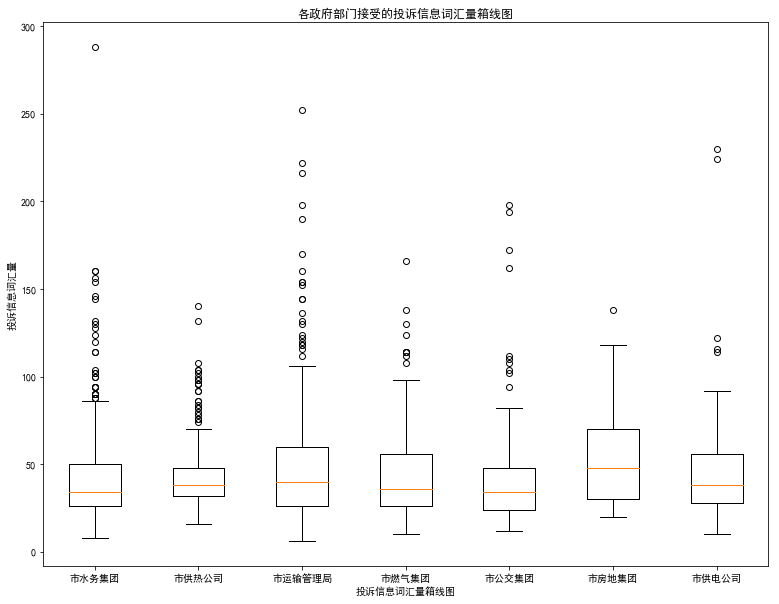

```python
words = []
for i in list:
    num = train.loc[i,:]  #索引相同的单位名称
    num["行总和"] = num.apply(lambda x:x.sum(),axis =1) #对相同单位名称的行，按行进行相加
    numbers = num["行总和"].values
    words.append(numbers)

words = np.array(words)

# 画出箱线图
plt.figure(figsize=(13,10))
labels = list
plt.boxplot([i for i in words],labels=labels)
plt.title("各政府部门接受的投诉信息词汇量箱线图",fontsize='large')
plt.xlabel('投诉信息词汇量箱线图',fontsize='medium')
plt.ylabel('投诉信息词汇量',fontsize='medium')
plt.show()
```

从图中我们可以看出，市房地集团接受到的投诉中，统计的投诉信息词汇量的中位数最大，说明相对于其他政府部分，他接受到的投诉建议中，用的词汇量最多，这也和现实中对于房地产业务的投诉中，情况很复杂且需要交流讨论的话题很多相符合。看中位数较低市水务集团、市公交集团，我们也能理解，因为一次投诉可能就是说哪个小区或者哪个家停水等投诉，词汇量相比房地集团的投诉肯定小得多。看箱子较小的市供热公司，1/4分位数和3/4分位数相差不大，说明每次投诉的词汇量变化不大。对离群值较多的市运输管理局的投诉，我们猜测，对市运输的投诉中，每次问题差异很大，导致会有很多离群值点。

## 分析问题四

以训练集中的政府单位为因变量类别，电话文本为自变量，尝试用朴素贝叶斯方法对市政电话文本进行分类，并使用该模型对测试集电话文本进行预测，计算混淆矩阵，简要分析模型的效果（提示：由于投诉建议文本整体长度较短，将每个词汇的被使用频数用是（1）-否（0）被使用替代，更为简便）

### 朴素贝叶斯分类

对训练集用GaussianNB建立朴素贝叶斯分类模型，并进行预测，与真实值进行比较，输出分类结果的评判标准。

```python
train_x = lines[1:,1:]  #(1900,6235)
train_y = np.array(data.iloc[:,0].map({'市水务集团':0, '市供热公司':1, '市运输管理局':2,
                                       '市燃气集团':3, '市公交集团':4, '市房地集团':5, '市供电公司':6})).reshape(-1,1)
train_x = np.array(train_x,dtype='float64') #<U10转float64
train_y = np.array(train_y,dtype='float64')
```

```python
from sklearn.naive_bayes import GaussianNB
#模型拟合
model = GaussianNB()
model.fit(train_x, train_y)
print(model)
```

```
GaussianNB(priors=None)
```

```python
#模型预测并查看效果 对训练集
from sklearn import metrics
pred = model.predict(train_x)
print(metrics.classification_report(train_y,pred))
```

```
             precision    recall  f1-score   support

        0.0       1.00      0.98      0.99       557
        1.0       1.00      0.99      1.00       332
        2.0       1.00      1.00      1.00       330
        3.0       1.00      1.00      1.00       285
        4.0       1.00      1.00      1.00       207
        5.0       0.93      1.00      0.96        96
        6.0       0.96      1.00      0.98        93

avg / total       0.99      0.99      0.99      1900
```

### 计算混淆矩阵并可视化

```
Text(33,0.5,'truth')
```

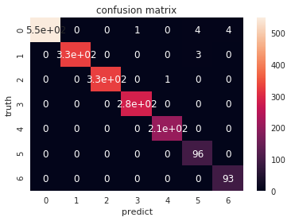

```python
import seaborn as sns
from sklearn.metrics import confusion_matrix

sns.set()
f,ax=plt.subplots()
C1= confusion_matrix(train_y, pred)
sns.heatmap(C1,annot=True,ax=ax)
ax.set_title('confusion matrix')
ax.set_xlabel('predict')
ax.set_ylabel('truth')
```

### 测试集上的分类

首先对测试集做与训练集相同的预处理，然后直接用训练集训过的模型来对输入的test_x预测pred，并与真实值test_y进行比较，输出分类评判标准，计算并可视化混淆矩阵。

```python
col = np.array([x.strip('"') for x in test_lines[0]])
idx = np.array([x.strip('"') for x in test_lines[:,0]])
test_lines[0] = col
test_lines[:,0] = idx

test_data = pd.DataFrame(test_lines[1:],columns=test_lines[0])

test_data.head()
test_data.columns.name = "id"
```

```python
test_x = test_lines[1:,1:]
test_y = np.array(test_data.iloc[:,0].map({'市水务集团':0, '市供热公司':1, '市运输管理局':2,
                                      '市燃气集团':3, '市公交集团':4, '市房地集团':5, '市供电公司':6})).reshape(-1,1)
test_x = np.array(test_x,dtype='float64')
test_y = np.array(test_y,dtype='float64')
```

```python
# 对测试集预测
pred = model.predict(test_x)
print(metrics.classification_report(test_y, pred))
```

```
             precision    recall  f1-score   support

        0.0       0.94      1.00      0.97        32
        1.0       0.94      0.88      0.91        17
        2.0       0.88      1.00      0.93        14
        3.0       0.80      1.00      0.89        12
        4.0       1.00      0.87      0.93        15
        5.0       0.50      0.33      0.40         6
        6.0       1.00      0.50      0.67         4

avg / total       0.90      0.90      0.89       100
```

```
Text(33,0.5,'truth')
```

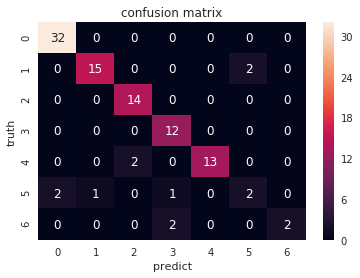

```python
sns.set()
f,ax=plt.subplots()
C2= confusion_matrix(test_y, pred)
sns.heatmap(C2,annot=True,ax=ax)
ax.set_title('confusion matrix')
ax.set_xlabel('predict')
ax.set_ylabel('truth')
```

### 结果分析

对该分类问题，我们使用朴素贝叶斯分类器，以我们的统计投诉词汇量中出现的投诉词汇的数量为自变量，判断该投诉属于哪个政府部门，因变量即为七个政府部分，将其映射到对应的0-6，分别代表七个部分。对1900条训练集而言，1900条数据中只预测错了13条，精确度、召回率、F1-score都达到了非常高的99%，说明效果非常好但可能存在过拟合的情况。对100条测试集而言，一共预测错了10条，精确度和召回率都达到了90%，F1-score达到了0.89，说明模型在测试集上的效果也挺好，模型有良好的鲁棒性。